# Practical Machine Learning. Course Project

Ekaterina Soboleva

May 25, 2019

## Introduction

This project is done as a Course Project of a Coursera course “[Practical Machine Learning](https://www.coursera.org/learn/practical-machine-learning/home/welcome)”, a part of “Data Science” specialization.

The data for the project is provided by **Human Activity Recognition** project (https://duckduckgo.com) that collects a large amount of data about personal activity. In this case, I will analyze data from accelerometers on the belt, forearm, arm, and dumbbell of 6 participants. They were asked to perform barbell lifts correctly and incorrectly in 5 different ways. The goal of this project is to predict the manner in which the participants did the exercise, i.e., Class A to E.

For complete the project we are provided with training and test data. The training data for this project are available here:

https://d396qusza40orc.cloudfront.net/predmachlearn/pml-training.csv

The test data are available here:

https://d396qusza40orc.cloudfront.net/predmachlearn/pml-testing.csv

## Loading and Preprocessing the Data

First, I load the data and take a look at them.

```r
dataURL_train <- "https://d396qusza40orc.cloudfront.net/predmachlearn/pml-training.csv"
dataURL_test <- "https://d396qusza40orc.cloudfront.net/predmachlearn/pml-testing.csv"
if(!file.exists("pml-training.csv")){
    download.file(dataURL_train, destfile = "pml-training.csv", method="curl")
    }
if(!file.exists("pml-testing.csv")){
    download.file(dataURL_test, destfile = "pml-testing.csv", method="curl")
    }
train_data <- read.csv("pml-training.csv")
test_data <- read.csv("pml-testing.csv")
```

```r
dim(train_data)
```

```
## [1] 19622   160
```

```r
dim(test_data)
```

```
## [1]  20 160
```

```r
str(train_data)
```

```
## 'data.frame':    19622 obs. of  160 variables:
##  $ X                       : int  1 2 3 4 5 6 7 8 9 10 ...
##  $ user_name               : Factor w/ 6 levels "adelmo","carlitos",..: 2 2 2 2 2 2 2 2 2 2 ...
##  $ raw_timestamp_part_1    : int  1323084231 1323084231 1323084231 1323084232 1323084232 1323084232 1323084232 1323084232 1323084232 1323084232 ...
##  $ raw_timestamp_part_2    : int  788290 808298 820366 120339 196328 304277 368296 440390 484323 484434 ...
##  $ cvtd_timestamp          : Factor w/ 20 levels "02/12/2011 13:32",..: 9 9 9 9 9 9 9 9 9 9 ...
##  $ new_window              : Factor w/ 2 levels "no","yes": 1 1 1 1 1 1 1 1 1 1 ...
##  $ num_window              : int  11 11 11 12 12 12 12 12 12 12 ...
##  $ roll_belt               : num  1.41 1.41 1.42 1.48 1.48 1.45 1.42 1.42 1.43 1.45 ...
##  $ pitch_belt              : num  8.07 8.07 8.07 8.05 8.07 8.06 8.09 8.13 8.16 8.17 ...
##  $ yaw_belt                : num  -94.4 -94.4 -94.4 -94.4 -94.4 -94.4 -94.4 -94.4 -94.4 -94.4 ...
##  $ total_accel_belt        : int  3 3 3 3 3 3 3 3 3 3 ...
##  $ kurtosis_roll_belt      : Factor w/ 397 levels "","-0.016850",..: 1 1 1 1 1 1 1 1 1 1 ...
##  $ kurtosis_picth_belt     : Factor w/ 317 levels "","-0.021887",..: 1 1 1 1 1 1 1 1 1 1 ...
##  $ kurtosis_yaw_belt       : Factor w/ 2 levels "","#DIV/0!": 1 1 1 1 1 1 1 1 1 1 ...
```

[output cut: 86 more lines]

We have data sets of 160 variables. The training set has 19 622 observations and the test set has 20. The information obtained by the **str()** function demonstrates the following features:

- some columns have a lot of NA values;
- first 7 columns probably contain information about the observation (what person did the exercise, when and how the information was collected).

I think it is necessary to clean the data to get a better prediction result. Here I do the following steps of cleaning:

- remove first 7 columns that contain data not useful for the analysis;
- remove the columns having only NA values;
- remove columns with near zero variance“.

```r
train_data <- train_data[,-c(1:7)]
train_data <- train_data[, colSums(is.na(train_data)) == 0]
train_NZ <- nearZeroVar(train_data)
train_data <- train_data[, -train_NZ]
dim(train_data)
```

```
## [1] 19622    53
```

Now we have the train data set of only 53 variables. I suppose that there is no need in types transformations (the variables are of “num”, “int” and “factor” types) and in correlation analysis (for this I rely on methods than will be used for model training).

## Data Partition and Analysis Plan

Here I divide the train data in two sub-sets - a sub-training (70%) and sub-test (30%) sata sets.

```r
set.seed(12345)
in_train <- createDataPartition(train_data$classe, p=0.7, list=FALSE)
train1 <- train_data[in_train,]
test1 <- train_data[-in_train,]
cbind(c("training", "testing"), rbind(dim(train1), dim(test1)))
```

```
##      [,1]       [,2]    [,3]
## [1,] "training" "13737" "53"
## [2,] "testing"  "5885"  "53"
```

I will try to apply three modeling methods and compare their characteristics to choose the best for the prediction:

- Classification Trees
- Random Forests
- Gradient Boosting Method

I shall use crossvalidation for reduce the effect of overfitting and improve the efficiency of the models. I’ve chosen a 5-folds cross validation method.

## Prediction with Classification Trees

Here I build a tree model with 5-folds cross validation and then estimate it’s in-sample and out-sample errors and accuracy.

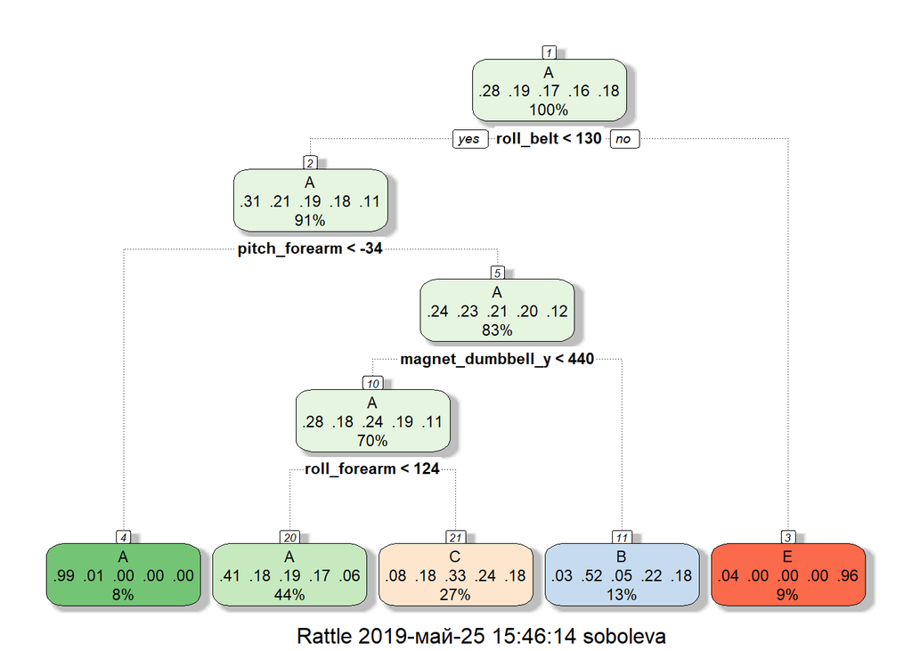

```r
tr_control <- trainControl(method="cv", number = 5)
model_tree <- train(classe ~ ., data = train1, method = "rpart", trControl = tr_control)
fancyRpartPlot(model_tree$finalModel)
```

```r
pred_train <- predict(model_tree, newdata = train1)
confMatrix_train <- confusionMatrix(train1$classe, pred_train)
confMatrix_train$table
```

```
##           Reference
## Prediction    A    B    C    D    E
##          A 3526   60  277    0   43
##          B 1111  906  641    0    0
##          C 1120   79 1197    0    0
##          D 1011  384  857    0    0
##          E  350  319  674    0 1182
```

```r
confMatrix_train$overall[1]
```

```
##  Accuracy
## 0.4958142
```

```r
pred_test <- predict(model_tree, newdata = test1)
confMatrix_test <- confusionMatrix(test1$classe, pred_test)
confMatrix_test$table
```

```
##           Reference
## Prediction    A    B    C    D    E
##          A 1494   21  128    0   31
##          B  470  380  289    0    0
##          C  467   29  530    0    0
##          D  438  184  342    0    0
##          E  141  147  277    0  517
```

```r
confMatrix_test$overall[1]
```

```
##  Accuracy
## 0.4963466
```

We can see from these results that the quality of the model is very poor:

- the both in-sample and out-sample errors are significant;
- the model accuracy is about 0.5 for both training and test data.

The model characteristics obtained definitively say that this model would be not useful for further predictions.

## Prediction with Random Forests

Now I’ll build a Random Forests model with 5-folds cross validation and look at its in-sample and out-sample errors and accuracy.

```r
tr_control <- trainControl(method="cv", number = 5)
model_forest <- train(classe ~ ., data = train1, method="rf", trControl = tr_control)
model_forest$finalModel
```

```
##
## Call:
##  randomForest(x = x, y = y, mtry = param$mtry)
##                Type of random forest: classification
##                      Number of trees: 500
## No. of variables tried at each split: 2
##
##         OOB estimate of  error rate: 0.64%
## Confusion matrix:
##      A    B    C    D    E class.error
## A 3901    4    1    0    0 0.001280082
## B   17 2636    5    0    0 0.008276900
## C    0   23 2372    1    0 0.010016694
## D    0    0   32 2218    2 0.015097691
## E    0    0    0    3 2522 0.001188119
```

```r
pred_train <- predict(model_forest, newdata = train1)
confMatrix_train <- confusionMatrix(train1$classe, pred_train)
confMatrix_train$table
```

```
##           Reference
## Prediction    A    B    C    D    E
##          A 3906    0    0    0    0
##          B    0 2658    0    0    0
##          C    0    0 2396    0    0
##          D    0    0    0 2252    0
##          E    0    0    0    0 2525
```

```r
confMatrix_train$overall[1]
```

```
## Accuracy
##        1
```

```r
pred_test <- predict(model_forest, newdata = test1)
confMatrix_test <- confusionMatrix(test1$classe, pred_test)
confMatrix_test$table
```

```
##           Reference
## Prediction    A    B    C    D    E
##          A 1673    1    0    0    0
##          B   12 1121    6    0    0
##          C    0   17 1006    3    0
##          D    0    0   24  940    0
##          E    0    0    0    3 1079
```

```r
confMatrix_test$overall[1]
```

```
## Accuracy
## 0.988785
```

This model seems to be very good - with accuracy 1 on the training data and 0.99 on the test data. It’s inspiring!

## Prediction with Gradient Boosting Method

Here I’ll try one more model and look at its characteristics.

```r
tr_control <- trainControl(method="cv", number = 5)
model_boost <- train(classe ~ ., data = train1, method = "gbm",
               trControl = tr_control, verbose = FALSE)
model_boost$finalModel
```

```
## A gradient boosted model with multinomial loss function.
## 150 iterations were performed.
## There were 52 predictors of which 52 had non-zero influence.
```

```r
pred_train <- predict(model_boost, newdata = train1)
confMatrix_train <- confusionMatrix(train1$classe, pred_train)
confMatrix_train$table
```

```
##           Reference
## Prediction    A    B    C    D    E
##          A 3876   18   10    1    1
##          B   58 2558   42    0    0
##          C    0   45 2329   20    2
##          D    2    5   51 2184   10
##          E    2   18   19   21 2465
```

```r
confMatrix_train$overall[1]
```

```
##  Accuracy
## 0.9763413
```

```r
pred_test <- predict(model_boost, newdata = test1)
confMatrix_test <- confusionMatrix(test1$classe, pred_test)
confMatrix_test$table
```

```
##           Reference
## Prediction    A    B    C    D    E
##          A 1651   16    4    3    0
##          B   34 1073   32    0    0
##          C    0   33  975   17    1
##          D    1    3   36  915    9
##          E    2   21    9   18 1032
```

```r
confMatrix_test$overall[1]
```

```
##  Accuracy
## 0.9593883
```

This model is also very good with the accuracy of 0.97 on training data and 0.96 on test data.

## Prediction on Test Data.

Here I try to do a prediction on test data by two models obtained by **random forests** and **gradient boosting** methods and compare the results.

```r
predict(model_forest, newdata = test_data)
```

```
##  [1] B A B A A E D B A A B C B A E E A B B B
## Levels: A B C D E
```

```r
predict(model_boost, newdata = test_data)
```

```
##  [1] B A B A A E D B A A B C B A E E A B B B
## Levels: A B C D E
```

The results obtained are equal that gives me a hope that my prediction of Classes for the test data will be precise!

## Conclusion

In this project, I applied tree modeling technics and compares their prediction quality in this particular case.

The **Classification Tree** appeared to be poor in this case. It is expected because the data set had many variables, much of them highly correlated. The **Gradient Boosting Regression** got a very good result, and the best result was got by the **Random Forests** method.